# Session06

Susumu Shikano

Last compiled at 31. Juli 2022

We first load a data set and extract the relevant variables:

```r
load("../data/Statistics_Exam_Anonymous.RData")


y <- exam.anonym$points[!is.na(exam.anonym$points)]
x <- exam.anonym$worksheet_submitted[!is.na(exam.anonym$points)]
n <- length(y)
```

We start with the one parameter model which only has the intercept and the variance of the normal distribution is fixed to 1. We create the likelihood function:

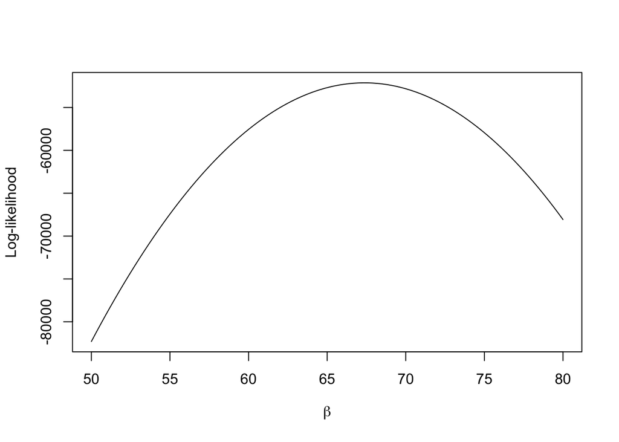

```r
LL.func <- function(beta){
  ((-(n/2)*log(2*pi)) - ((1/(2))*sum((y - beta)^2)))
  #-sum((y - beta)^2)*-1
}

x.s <- seq(50,80,length=100)

outputs <- rep(NA,length(x.s) )
for (i in 1:length(x.s)){
  outputs[i] <- LL.func(x.s[i])
}

plot(x.s,outputs,type="l", ylab="Log-likelihood",xlab=expression(beta))
```

You create the inverse function of the the above function since the $mle2()$ function does not maximize, but minimize the function:

```r
minusLL.1 <- function(beta){
  LL.func(beta) *-1
}
```

By minimizing the function, we obtain the results:

```r
fit.1 <- mle2(minusLL.1,list(beta=50))
summary(fit.1)
```

```
## Maximum likelihood estimation
##
## Call:
## mle2(minuslogl = minusLL.1, start = list(beta = 50))
##
## Coefficients:
##       Estimate Std. Error z value     Pr(z)
## beta 67.370000   0.070711  952.76 < 2.2e-16 ***
## ---
## Signif. codes:  0 '***' 0.001 '**' 0.01 '*' 0.05 '.' 0.1 ' ' 1
##
## -2 log L: 104248.2
```

We can also obtain the maximum value of the log-likelihood function, which can be checked against the plotted likelihood function above:

```r
print(max.ll <- fit.1@details$value *-1)
```

```
## [1] -52124.1
```

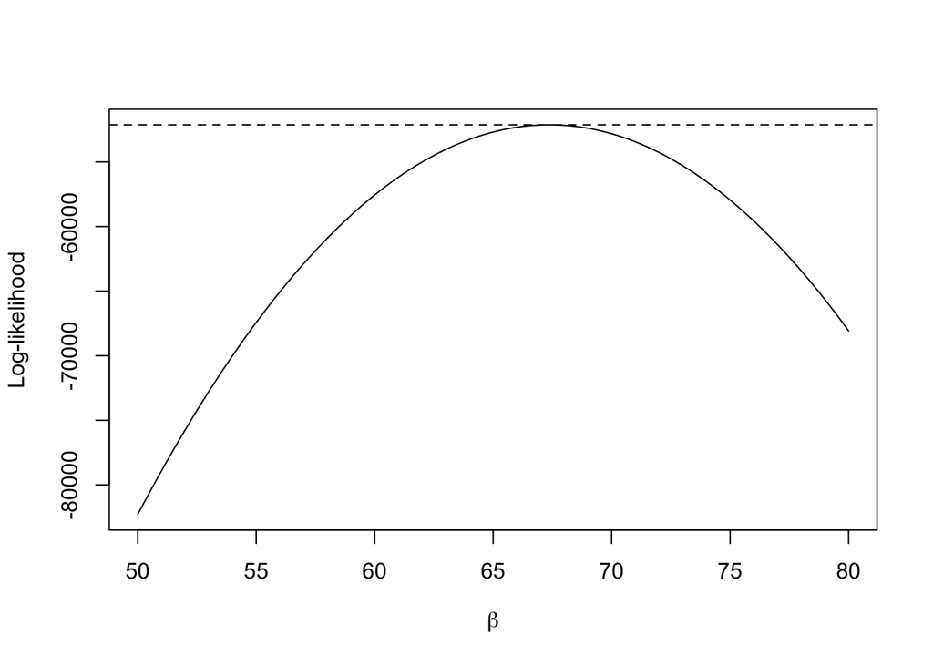

```r
plot(x.s,outputs,type="l", ylab="Log-likelihood",xlab=expression(beta))
abline(h=max.ll,lty=2)
```

We include in the next model the explanatory variable (number of submitted worksheets):

```r
minusLL.2 <- function(beta0, beta1) {
  ((-(n/2)*log(2*pi)) - ((1/(2))*sum((y - beta0 - beta1*x)^2)))*-1
  #-sum((y - beta0 - beta1 * x)^2)*-1
  }

fit.2 <- mle2(minusLL.2,list(beta0=50,beta1=0.5))
summary(fit.2)
```

```
## Maximum likelihood estimation
##
## Call:
## mle2(minuslogl = minusLL.2, start = list(beta0 = 50, beta1 = 0.5))
##
## Coefficients:
##        Estimate Std. Error z value     Pr(z)
## beta0 39.609073   0.204979  193.23 < 2.2e-16 ***
## beta1  4.347835   0.030133  144.29 < 2.2e-16 ***
## ---
## Signif. codes:  0 '***' 0.001 '**' 0.01 '*' 0.05 '.' 0.1 ' ' 1
##
## -2 log L: 83428.54
```

```r
fit.2@details$value
```

```
## [1] 41714.27
```

We can also estimate $\sigma^2$ (variance) as well:

```r
minusLL.3 <- function(beta0,beta1,sigma2){
  #((-(n/2)*log(2*pi*sigma2)) - ((1/(2*sigma2))*sum((y - beta0 - beta1*x)^2)))*-1
  mu <- beta0 + beta1*x
  ll <- suppressWarnings(dnorm(y,  mean=mu, sd=sqrt(sigma2),log = TRUE))
  -sum(ll)
}

fit.3 <- mle2(minusLL.3,list(beta0=50,beta1=0.5,sigma2=3))
summary(fit.3)
```

```
## Maximum likelihood estimation
##
## Call:
## mle2(minuslogl = minusLL.3, start = list(beta0 = 50, beta1 = 0.5,
##     sigma2 = 3))
##
## Coefficients:
##         Estimate Std. Error z value     Pr(z)
## beta0   39.60786    4.16706  9.5050 < 2.2e-16 ***
## beta1    4.34798    0.61257  7.0979 1.266e-12 ***
## sigma2 413.27552   41.12610 10.0490 < 2.2e-16 ***
## ---
## Signif. codes:  0 '***' 0.001 '**' 0.01 '*' 0.05 '.' 0.1 ' ' 1
##
## -2 log L: 1773.38
```

```r
fit.3@details$value
```

```
## [1] 886.6902
```

We can also use another algorithm to find the maximum likelihood:

```r
fit.3nlm <- mle2(minusLL.3,optimizer="nlm",list(beta0=50,beta1=0.5,sigma2=3))
summary(fit.3nlm)
```

```
## Maximum likelihood estimation
##
## Call:
## mle2(minuslogl = minusLL.3, start = list(beta0 = 50, beta1 = 0.5,
##     sigma2 = 3), optimizer = "nlm")
##
## Coefficients:
##         Estimate Std. Error z value     Pr(z)
## beta0   39.60900    4.17727  9.4820 < 2.2e-16 ***
## beta1    4.34784    0.61407  7.0803 1.438e-12 ***
## sigma2 415.30468   41.53045 10.0000 < 2.2e-16 ***
## ---
## Signif. codes:  0 '***' 0.001 '**' 0.01 '*' 0.05 '.' 0.1 ' ' 1
##
## -2 log L: 1773.378
```

```r
fit.3nlm@details$minimum
```

```
## [1] 886.689
```

Now we compare all the models above:

```r
summary(fit.1)
```

```
## Maximum likelihood estimation
##
## Call:
## mle2(minuslogl = minusLL.1, start = list(beta = 50))
##
## Coefficients:
##       Estimate Std. Error z value     Pr(z)
## beta 67.370000   0.070711  952.76 < 2.2e-16 ***
## ---
## Signif. codes:  0 '***' 0.001 '**' 0.01 '*' 0.05 '.' 0.1 ' ' 1
##
## -2 log L: 104248.2
```

```r
summary(fit.2)
```

```
## Maximum likelihood estimation
##
## Call:
## mle2(minuslogl = minusLL.2, start = list(beta0 = 50, beta1 = 0.5))
##
## Coefficients:
##        Estimate Std. Error z value     Pr(z)
## beta0 39.609073   0.204979  193.23 < 2.2e-16 ***
## beta1  4.347835   0.030133  144.29 < 2.2e-16 ***
## ---
## Signif. codes:  0 '***' 0.001 '**' 0.01 '*' 0.05 '.' 0.1 ' ' 1
##
## -2 log L: 83428.54
```

```r
summary(fit.3)
```

```
## Maximum likelihood estimation
##
## Call:
## mle2(minuslogl = minusLL.3, start = list(beta0 = 50, beta1 = 0.5,
##     sigma2 = 3))
##
## Coefficients:
##         Estimate Std. Error z value     Pr(z)
## beta0   39.60786    4.16706  9.5050 < 2.2e-16 ***
## beta1    4.34798    0.61257  7.0979 1.266e-12 ***
## sigma2 413.27552   41.12610 10.0490 < 2.2e-16 ***
## ---
## Signif. codes:  0 '***' 0.001 '**' 0.01 '*' 0.05 '.' 0.1 ' ' 1
##
## -2 log L: 1773.38
```

Finally, we can compare all above results with the OLS estimates:

```r
summary(lm(y ~ x))
```

```
##
## Call:
## lm(formula = y ~ x)
##
## Residuals:
##    Min     1Q Median     3Q    Max
## -56.70 -12.90   4.00  13.91  51.39
##
## Coefficients:
##             Estimate Std. Error t value Pr(>|t|)
## (Intercept)  39.6091     4.1983   9.435   <2e-16 ***
## x             4.3478     0.6172   7.045    3e-11 ***
## ---
## Signif. codes:  0 '***' 0.001 '**' 0.01 '*' 0.05 '.' 0.1 ' ' 1
##
## Residual standard error: 20.48 on 198 degrees of freedom
## Multiple R-squared:  0.2004, Adjusted R-squared:  0.1964
## F-statistic: 49.63 on 1 and 198 DF,  p-value: 3.001e-11
```

Here some exercises until tomorrow:

- Calculate the log-likelihood ratio for all pairs of the models above.
- Which specific probability distribution will be used to decide whether to take the restrictive or unrestrictive model? Which threshold value will be compared with the above log-likelihood ratio?
- Check the results of the ML- (Model 3) and OLS-estimator above whether there are any differences. If yes, consider why.